# Chapter 2 - Data wrangling and analysis

## Introducing the data

First we read the students2014 data, which is provided in a website. After that, we look at what the data consist of.

```r
# Download the data

students2014 <- read.table("http://s3.amazonaws.com/assets.datacamp.com/production/course_2218/datasets/learning2014.txt ", sep=",", header=TRUE)

# First look at the data

head(students2014)
```

```
##   gender age attitude     deep  stra     surf points
## 1      F  53      3.7 3.583333 3.375 2.583333     25
## 2      M  55      3.1 2.916667 2.750 3.166667     12
## 3      F  49      2.5 3.500000 3.625 2.250000     24
## 4      M  53      3.5 3.500000 3.125 2.250000     10
## 5      M  49      3.7 3.666667 3.625 2.833333     22
## 6      F  38      3.8 4.750000 3.625 2.416667     21
```

```r
# Look at the dimensions and structures of the data

dim(students2014)
```

```
## [1] 166   7
```

```r
str(students2014)
```

```
## 'data.frame':    166 obs. of  7 variables:
##  $ gender  : Factor w/ 2 levels "F","M": 1 2 1 2 2 1 2 1 2 1 ...
##  $ age     : int  53 55 49 53 49 38 50 37 37 42 ...
##  $ attitude: num  3.7 3.1 2.5 3.5 3.7 3.8 3.5 2.9 3.8 2.1 ...
##  $ deep    : num  3.58 2.92 3.5 3.5 3.67 ...
##  $ stra    : num  3.38 2.75 3.62 3.12 3.62 ...
##  $ surf    : num  2.58 3.17 2.25 2.25 2.83 ...
##  $ points  : int  25 12 24 10 22 21 21 31 24 26 ...
```

So the data include:

- demographic information about students (age, gender)
- the student’s attitude score towards statistics based on a questionnare (attitude)
- student exam points (points)
- student scores on deep learning based on a questionnare (deep)
- student scores on strategic learning based on a questionnare (stra)
- student scores on surface-level learning based on a questionnare (surf)

The data frame has 166 observations (rows) and 7 variables (columns). When we take a look at the structure, most individual observations are numerical. Two columns include integers (age, points) and one includes factors (gender).

Let’s look at a summary of the observations.

```r
summary(students2014)
```

```
##  gender       age           attitude          deep            stra
##  F:110   Min.   :17.00   Min.   :1.400   Min.   :1.583   Min.   :1.250
##  M: 56   1st Qu.:21.00   1st Qu.:2.600   1st Qu.:3.333   1st Qu.:2.625
##          Median :22.00   Median :3.200   Median :3.667   Median :3.188
##          Mean   :25.51   Mean   :3.143   Mean   :3.680   Mean   :3.121
##          3rd Qu.:27.00   3rd Qu.:3.700   3rd Qu.:4.083   3rd Qu.:3.625
##          Max.   :55.00   Max.   :5.000   Max.   :4.917   Max.   :5.000
##       surf           points
##  Min.   :1.583   Min.   : 7.00
##  1st Qu.:2.417   1st Qu.:19.00
##  Median :2.833   Median :23.00
##  Mean   :2.787   Mean   :22.72
##  3rd Qu.:3.167   3rd Qu.:27.75
##  Max.   :4.333   Max.   :33.00
```

Most of the students are women and most students are in their 20s. The oldest student is 55 years old. Based on the summary, attitude, deep, strategic and surface scores have a scale from 1-5. The highest exam points has been 33 points, and most of the points were above 20.

## Graphical overview of the data

Let’s plot the whole dataset to get a general idea, how the data behave in pairs.

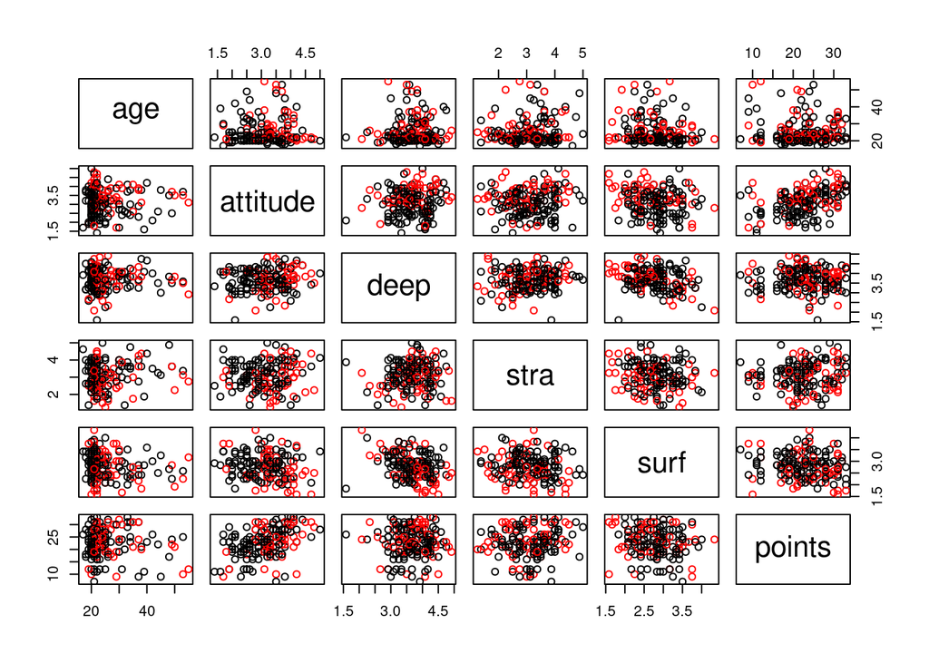

```r
plot(students2014[-1], col = students2014$gender)
```

This plot can be used to observe possible trends. We are interested in discovering which variable contributes to high or low exam points. For this reason, we’ll take a look at the last row or at the right most column, since exam points are paired to other variables on those sets. For example, on the second column’s (attitude) last row (points) we see some form of correlation. The data points scew from the lower left corner to the upper right corner in a similar fashion to a trend line, giving us a clue that the exam points seem to be high (or low) when the attitude scores are high (or low).

We can use ggplot2 and GGally packages to generate a more advanced plot. Disregard the “upper” part inside the ggpairs command if you’re not using Linux. Otherwise FYI for Linux users: Ubuntu has some font issues with GGally and that part of the code is a workaround.

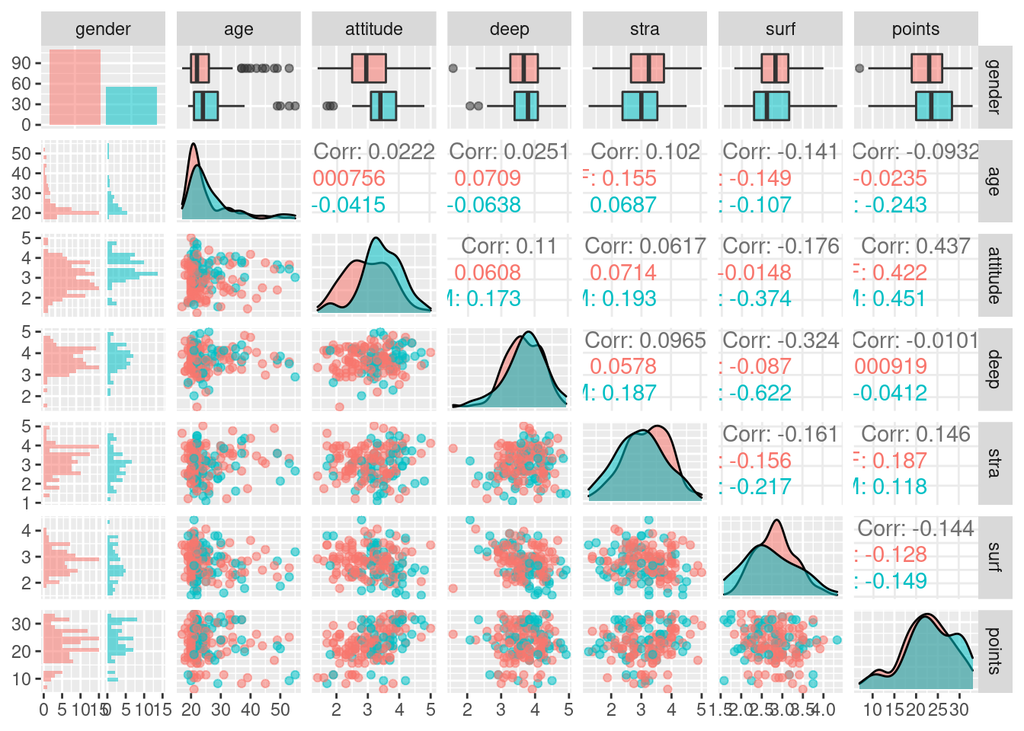

```r
library(ggplot2)
library(GGally)

plot <- ggpairs(students2014, mapping = aes(col=gender, alpha = 0.3), upper = list(continuous = "cor_v1_5"), lower = list(combo = wrap("facethist", bins = 20)))

plot
```

We get some additional information out of this plot. It is important to look at the correlation values (Corr). The higher the absolute value, the greater the correlation between the variables. We observe that points and attitude have a positive correlation value of 0.437, which is the highest in this dataset. Other correlations worth noting are strategic and surface, which both have approximately a 0.14 value. Surface scores correlate negatively with points since the value is negative.

## Regression model

Since attitude, surf and stra are most correlated with points, we’ll fit a linear model on these variables. Our variable of interest is points (y) and our explanatory variables (x) are attitude, stra and surf.

```r
model <- lm(points ~ attitude + surf + stra, data = students2014)

summary(model)
```

```
##
## Call:
## lm(formula = points ~ attitude + surf + stra, data = students2014)
##
## Residuals:
##      Min       1Q   Median       3Q      Max
## -17.1550  -3.4346   0.5156   3.6401  10.8952
##
## Coefficients:
##             Estimate Std. Error t value Pr(>|t|)
## (Intercept)  11.0171     3.6837   2.991  0.00322 **
## attitude      3.3952     0.5741   5.913 1.93e-08 ***
## surf         -0.5861     0.8014  -0.731  0.46563
## stra          0.8531     0.5416   1.575  0.11716
## ---
## Signif. codes:  0 '***' 0.001 '**' 0.01 '*' 0.05 '.' 0.1 ' ' 1
##
## Residual standard error: 5.296 on 162 degrees of freedom
## Multiple R-squared:  0.2074, Adjusted R-squared:  0.1927
## F-statistic: 14.13 on 3 and 162 DF,  p-value: 3.156e-08
```

From our summary we see that only attitude has a significant correlation (p < 0.001) with points. Surf and stra don’t correlate significantly with points. We’ll run the model again with attitude only, since surf and stra were unnecessarily included.

```r
model <- lm(points ~ attitude, data = students2014)

summary(model)
```

```
##
## Call:
## lm(formula = points ~ attitude, data = students2014)
##
## Residuals:
##      Min       1Q   Median       3Q      Max
## -16.9763  -3.2119   0.4339   4.1534  10.6645
##
## Coefficients:
##             Estimate Std. Error t value Pr(>|t|)
## (Intercept)  11.6372     1.8303   6.358 1.95e-09 ***
## attitude      3.5255     0.5674   6.214 4.12e-09 ***
## ---
## Signif. codes:  0 '***' 0.001 '**' 0.01 '*' 0.05 '.' 0.1 ' ' 1
##
## Residual standard error: 5.32 on 164 degrees of freedom
## Multiple R-squared:  0.1906, Adjusted R-squared:  0.1856
## F-statistic: 38.61 on 1 and 164 DF,  p-value: 4.119e-09
```

The p value became slightly more significant compared to our previous model. Additionally, we observe that attitude has a positive correlation with points since the estimate value is greater than zero. The intercept refers to the point where the regression line intercepts with y axis, so when x (attitude) is zero, y (points) is 11.6372. The intercept value is statistically significant (p < 0.001).

## Model diagnostics

To confirm our model works for our data, we’ll run some diagnostics. Let’s generate the plots first.

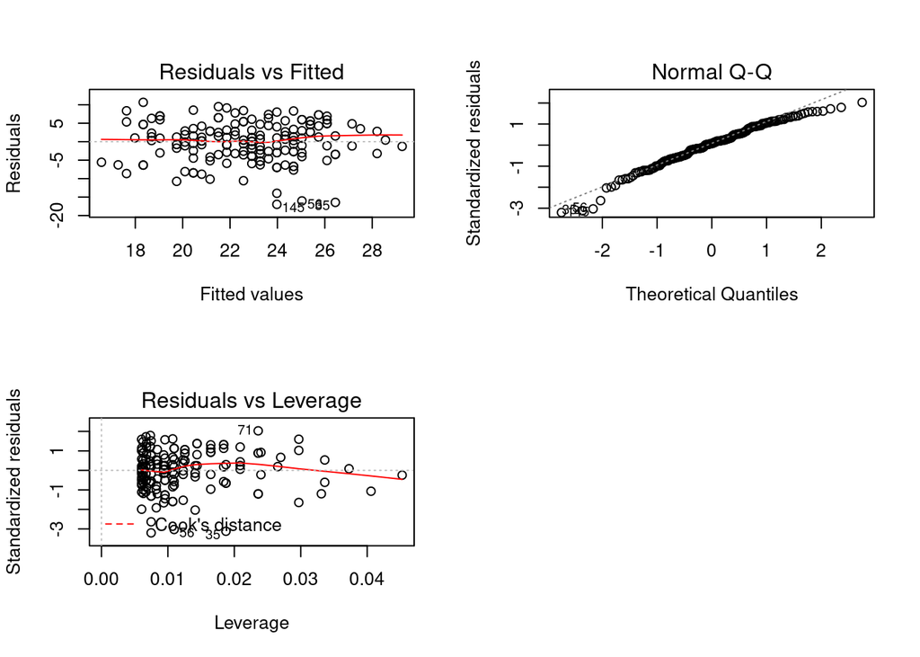

```r
par(mfrow = c(2,2))
plot(model, which = c(1,2,5))
```

Linear model assumes the residuals are normally distributed with a constant variance and that they don’t correlate. From the Residuals vs. Fitted plot we observe that the data points vary in a quite random fashion. For example, if the data points were more close to each other on the left side but scattered on the right side, we would have a problem.

Q-Q plot is used to confirm the normality assumption: the better the points fall on the line, the better the model fit. Some of the points in the beginning and end of the line stray, but overall the points follow our dashes quite nicely.

Residuals vs. Leverage is used for the dependacy assumption. We can to identify outliers, if necessary. In our plot, there are no identifiable outliers, since the data points are fairly close to each other, which the x axis values confirm. If the x axis values were greater and there was a single point far away from the other data points, we would have to reconsider our model.

Overall, our diagnostics show that our linear model can be used to fit the data.